# Sampling Elemzés — Long Champion Modell

- Show All Code
- Hide All Code

lgbm_solusdt_l_fw60_2101_2605 | train/valid periódus vizsgálat

Published

2026-06-29

```python
# Parameters — modify these to analyze a different model
MODEL_ID  = "lgbm_solusdt_l_fw60_2101_2605"
DIRECTION = "long"   # "long" or "short"
TARGET    = "long_mfe_fw60"   # "long_mfe_fw60" or "short_mfe_fw60"
```

```python
# Parameters
MODEL_ID = "lgbm_solusdt_l_fw60_2101_2605"
DIRECTION = "long"
TARGET = "long_mfe_fw60"
```

```python
import sys
from pathlib import Path
import duckdb
import pandas as pd
import numpy as np
import seaborn as sns
import matplotlib.pyplot as plt
import matplotlib.ticker as mtick
import matplotlib.dates as mdates
from IPython.display import display, Markdown

from analyst.lib.db_utils import find_repo_root, lab_db_path, db_path as _live_db_path
from analyst.lib.plot_utils import CQ_COLORS, CQ_SEQUENCE, setup_cq_theme
from analyst.lib.table_formatting import format_analysis_table, display_analysis_table

_root = find_repo_root()
sys.path.insert(0, str(_root))
sys.path.insert(0, str(_root / "src"))
setup_cq_theme()

# --- Adatbetöltés ---
LAB_DB = lab_db_path()
LIVE_DB = _live_db_path()

con = duckdb.connect(LAB_DB, read_only=True)
df = con.execute(
    f'SELECT open_time, {TARGET}, split FROM model."{MODEL_ID}__sample"'
).fetchdf()
con.close()

df["open_time"] = pd.to_datetime(df["open_time"])
df["segment"] = df["split"].map({0: "Train", 1: "Valid"})

VALID_START = df[df["segment"] == "Valid"]["open_time"].min()
```

## 1 Cél

**Kapcsolódó dokumentáció:** - Módszertan: `_doc_/methodology_doc/3000_sampling.md` - Kód-dokumentáció: `_doc_/database_and_code_doc/5300_create_sample.md`

**Asset:** SOLUSDT | **Granularitás:** 1m (óránkénti mintavétel) | **Dátum:** 2026-06-29

## 2 1. Train / Valid összesítő

**Mi ez.** Az összes sample-sor szétválasztva train (split=0) és valid (split=1) szerint.

**Értelmezés.** Megmutatja, arányos-e a train/valid felosztás, és van-e eltérés az átlagos target szintjében a két periódus között.

```python
summary = (
    df.groupby("segment")
    .agg(
        n_obs=("open_time", "count"),
        min_date=("open_time", "min"),
        max_date=("open_time", "max"),
        avg_target=(TARGET, "mean"),
        negative_rate=(TARGET, lambda x: (x < 0).mean()),
    )
    .reset_index()
)
summary["min_date"] = summary["min_date"].dt.strftime("%Y-%m-%d")
summary["max_date"] = summary["max_date"].dt.strftime("%Y-%m-%d")
summary = summary.rename(columns={
    "segment": "Szegmens",
    "n_obs": "Megfigyelések (db)",
    "min_date": "Első adat",
    "max_date": "Utolsó adat",
    "avg_target": "Átlag short_mfe_fw60",
    "negative_rate": "Negatív arány (short nyereség)",
})
display_analysis_table(summary)
```

Table 1: Train és Valid összesítő — megfigyelésszám, időtartam, átlagos short_mfe_fw60, negatív arány

| Szegmens | Megfigyelések (db) | Első adat | Utolsó adat | Átlag short_mfe_fw60 | Negatív arány (short nyereség) |
| --- | --- | --- | --- | --- | --- |
| Train | 37939 | 2021-01-01 | 2025-04-30 | 0.008 | 0.069 |
| Valid | 9504 | 2025-05-01 | 2026-05-31 | 0.005 | 0.060 |

## 3 2. Havi target alakulása

**Mi ez.** A `short_mfe_fw60` havi átlaga és szórássávja a teljes mintavételi perióduson.

**Módszer.** Havi bontású csoportosítás: átlag és szórás kiszámítása `short_mfe_fw60`-ra. A vonal az átlagot, a sáv (±1σ) a szórást mutatja. A narancs terület jelöli a valid időszakot (2025-05 –), a szaggatott vonal a train/valid határt.

**Értelmezés.** Megmutatja, hogy a target átlagos szintje stabil-e az időben, és van-e rezsimváltás a train és valid periódus között. Negatív értékek kedvezők (profitábilis short irány).

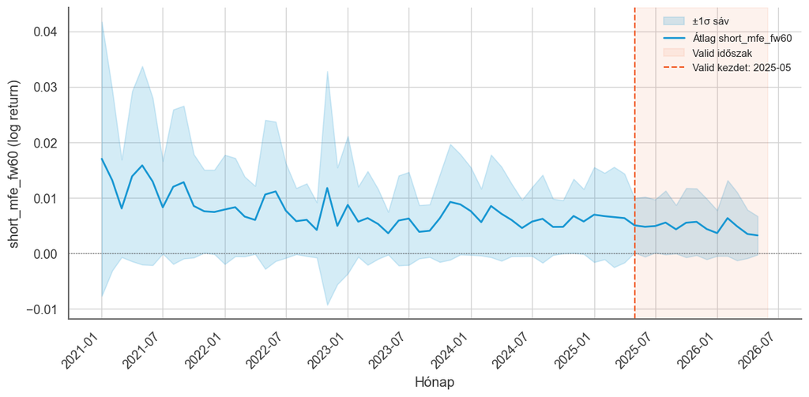

Figure 1: Havi átlagos short_mfe_fw60 és ±1σ szórássáv — train (kék) / valid (narancs terület)

```python
df["month"] = df["open_time"].dt.to_period("M")
monthly = (
    df.groupby("month")
    .agg(avg_target=(TARGET, "mean"), std_target=(TARGET, "std"))
    .reset_index()
)
monthly["date"] = monthly["month"].dt.to_timestamp()
monthly["upper"] = monthly["avg_target"] + monthly["std_target"]
monthly["lower"] = monthly["avg_target"] - monthly["std_target"]

valid_start_month = VALID_START.replace(day=1)
plot_end = monthly["date"].max() + pd.DateOffset(months=1)

fig, ax = plt.subplots(figsize=(10, 5))

ax.fill_between(
    monthly["date"], monthly["lower"], monthly["upper"],
    alpha=0.18, color=CQ_COLORS["blue"], label="±1σ sáv"
)
ax.plot(
    monthly["date"], monthly["avg_target"],
    color=CQ_COLORS["blue"], linewidth=1.6, label="Átlag short_mfe_fw60"
)
ax.axvspan(
    valid_start_month, plot_end,
    alpha=0.08, color=CQ_COLORS["orange"], label="Valid időszak"
)
ax.axvline(
    valid_start_month, color=CQ_COLORS["orange"],
    linewidth=1.3, linestyle="--",
    label=f"Valid kezdet: {VALID_START.strftime('%Y-%m')}"
)
ax.axhline(0, color=CQ_COLORS["gray"], linewidth=0.8, linestyle=":")

ax.xaxis.set_major_formatter(mdates.DateFormatter("%Y-%m"))
ax.xaxis.set_major_locator(mdates.MonthLocator(bymonth=[1, 7]))
plt.xticks(rotation=45, ha="right")
ax.set_xlabel("Hónap")
ax.set_ylabel("short_mfe_fw60 (log return)")
ax.legend(loc="upper right", fontsize=9)
plt.tight_layout()
plt.show()
```

## 4 3. Target eloszlása (Train vs Valid)

**Mi ez.** A `short_mfe_fw60` eloszlásának összehasonlítása train és valid periódus között.

**Módszer.** (a) KDE sűrűségbecslés: train és valid eloszlás egymáson; (b) boxplot: train és valid egymás mellett — medián, IQR és outlier-ek vizualizálva.

**Értelmezés.** Az eloszlások hasonlósága jelzi, hogy a valid periódus reprezentatív-e a train mintához képest. Jelentős eltolódás rezsimváltást vagy distribution shift-et jelez. Short modellnél a negatív oldal a profitábilis rész.

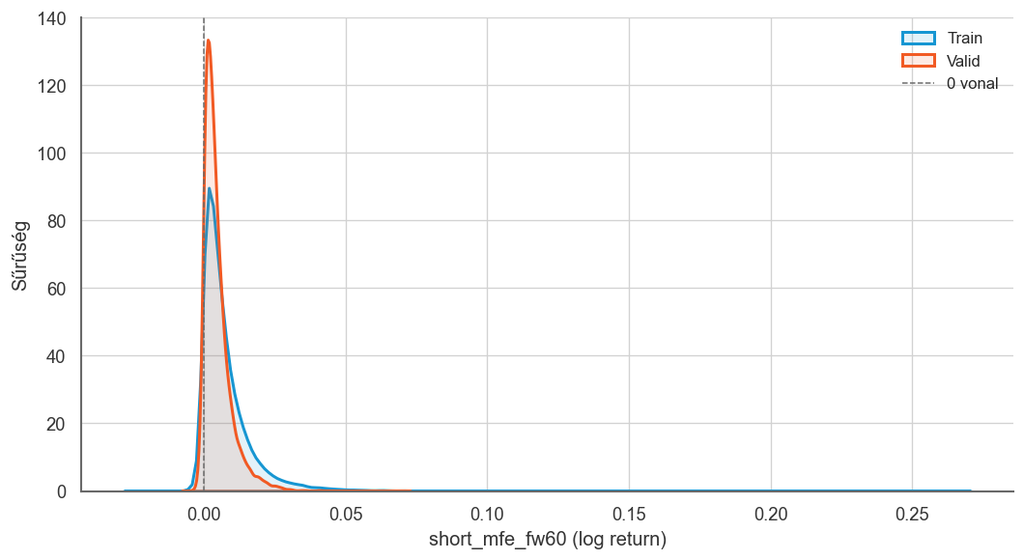

Figure 2: short_mfe_fw60 eloszlása — Train (kék) és Valid (narancs) KDE egymáson

```python
train_data = df[df["segment"] == "Train"][TARGET]
valid_data = df[df["segment"] == "Valid"][TARGET]

fig, ax = plt.subplots(figsize=(9, 5))
sns.kdeplot(
    train_data, ax=ax,
    color=CQ_COLORS["blue"], label="Train",
    linewidth=1.8, fill=True, alpha=0.12
)
sns.kdeplot(
    valid_data, ax=ax,
    color=CQ_COLORS["orange"], label="Valid",
    linewidth=1.8, fill=True, alpha=0.12
)
ax.axvline(0, color=CQ_COLORS["gray"], linewidth=0.9, linestyle="--", label="0 vonal")
ax.set_xlabel("short_mfe_fw60 (log return)")
ax.set_ylabel("Sűrűség")
ax.legend(fontsize=10)
plt.tight_layout()
plt.show()
```

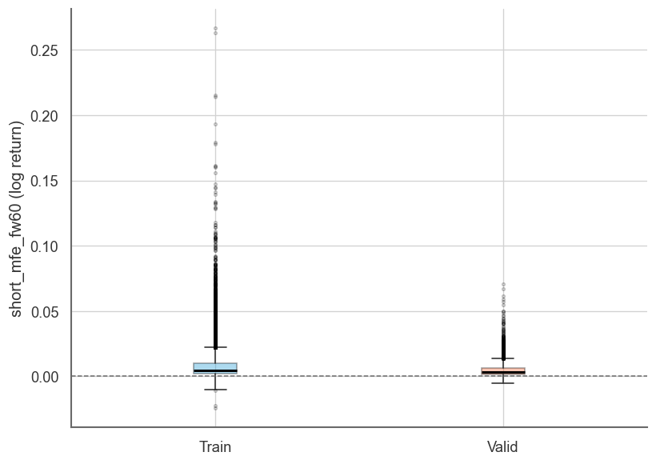

Figure 3: short_mfe_fw60 boxplot — Train és Valid egymás mellett

```python
segments = ["Train", "Valid"]
colors_bp = [CQ_COLORS["blue"], CQ_COLORS["orange"]]
data_by_seg = [train_data.values, valid_data.values]

fig, ax = plt.subplots(figsize=(7, 5))
bp = ax.boxplot(
    data_by_seg,
    labels=segments,
    patch_artist=True,
    medianprops=dict(color=CQ_COLORS["black"], linewidth=1.8),
    whiskerprops=dict(linewidth=1.0, color=CQ_COLORS["gray_dark"]),
    capprops=dict(linewidth=1.0, color=CQ_COLORS["gray_dark"]),
    flierprops=dict(marker="o", markersize=2, alpha=0.25, color=CQ_COLORS["gray"]),
    showfliers=True,
)
for patch, color in zip(bp["boxes"], colors_bp):
    patch.set_facecolor(color)
    patch.set_alpha(0.35)

ax.axhline(0, color=CQ_COLORS["gray"], linewidth=0.9, linestyle="--")
ax.set_ylabel("short_mfe_fw60 (log return)")
plt.tight_layout()
plt.show()
```

## 5 Értelmezés

```python
rows = []
for seg, data in [("Train", train_data), ("Valid", valid_data)]:
    rows.append({
        "Szegmens": seg,
        "Medián": data.median(),
        "Átlag": data.mean(),
        "Szórás (σ)": data.std(),
        "IQR": data.quantile(0.75) - data.quantile(0.25),
        "Negatív arány (short nyereség)": (data < 0).mean(),
    })
interp_df = pd.DataFrame(rows)
display_analysis_table(interp_df)
```

Table 2: Összehasonlító metrikák — Train vs Valid

| Szegmens | Medián | Átlag | Szórás (σ) | IQR | Negatív arány (short nyereség) |
| --- | --- | --- | --- | --- | --- |
| Train | 0.005 | 0.008 | 0.011 | 0.008 | 0.069 |
| Valid | 0.003 | 0.005 | 0.005 | 0.005 | 0.060 |

## 6 4. Top10 decilis havi bontásban — Train és Valid

**Struktúra.** Train és Valid hónapjai egyetlen táblában, éves összesítő sorokkal. Short modellnél a **top10 = a legalacsonyabb (leg-negatívabb) értékek** — P10 küszöb szegmensenkénti. A top10 küszöböt szegmensenkéből külön számoljuk: **P10 (train)** és **P10 (valid)**.

**Tábla.** Szegmens / Időszak / N sample / N top10 / Top10 avg target / Top10 / hét / Top10 / nap — az éves összesítő sorok dőlten szedve.

```python
train_df = df[df["segment"] == "Train"][["open_time", TARGET]].copy()
valid_df = df[df["segment"] == "Valid"][["open_time", TARGET]].copy()

# Short esetén a top10 = a legalacsonyabb (leg-negatívabb) értékek => P10
p10_train = np.percentile(train_df[TARGET].dropna(), 10)
p10_valid = np.percentile(valid_df[TARGET].dropna(), 10)

t10_train_avg = train_df[train_df[TARGET] <= p10_train][TARGET].mean()
t10_valid_avg = valid_df[valid_df[TARGET] <= p10_valid][TARGET].mean()
global_avg    = valid_df[TARGET].mean()

# P10 + top10 avg referenciatábla
ref_df = pd.DataFrame([
    {"Metrika": "P10 küszöb (szegmensenkénti — short: legnegatívabb 10%)",  "Train": f"{p10_train:.5f}", "Valid": f"{p10_valid:.5f}"},
    {"Metrika": "Top10 avg target (short: legnegatívabb értékek átlaga)",   "Train": f"{t10_train_avg:.5f}", "Valid": f"{t10_valid_avg:.5f}"},
    {"Metrika": "Teljes szegmens avg target",                                "Train": f"{train_df[TARGET].mean():.5f}", "Valid": f"{valid_df[TARGET].mean():.5f}"},
    {"Metrika": "Lift (|top10_avg| / |segment_avg|)",                        "Train": f"{abs(t10_train_avg) / abs(train_df[TARGET].mean()):.3f}x", "Valid": f"{abs(t10_valid_avg) / abs(valid_df[TARGET].mean()):.3f}x"},
])
display_analysis_table(ref_df)

# Heti grid a teljes adatperióduson
all_start = df["open_time"].min().normalize()
all_end   = df["open_time"].max().normalize() + pd.Timedelta(days=1)
week_starts_all = pd.date_range(start=all_start, end=all_end, freq="7D")

# Havi + éves aggregátum build
monthly_rows = []
for seg_label, seg_df, p10 in [("Train", train_df, p10_train), ("Valid", valid_df, p10_valid)]:
    sd = seg_df.copy()
    sd["top10"] = sd[TARGET] <= p10  # short: leg-negatívabb értékek
    sd["ym"]    = sd["open_time"].dt.to_period("M")
    sd["year"]  = sd["open_time"].dt.year

    for year, ydf in sd.groupby("year"):
        for ym, mdf in ydf.groupby("ym"):
            n_s = len(mdf)
            n_t = int(mdf["top10"].sum())
            n_d = ym.days_in_month
            n_w = sum(1 for ws in week_starts_all if ws.strftime("%Y-%m") == str(ym))
            t_avg = mdf[mdf["top10"]][TARGET].mean() if n_t else np.nan
            monthly_rows.append({
                "_order": 0,
                "Szegmens": seg_label,
                "Időszak":  str(ym),
                "N sample": n_s,
                "N top10":  n_t,
                "Top10 avg target (short: legnegatívabb)": round(t_avg, 5) if not np.isnan(t_avg) else None,
                "Top10 / hét":      round(n_t / n_w, 1) if n_w else None,
                "Top10 / nap":      round(n_t / n_d, 2),
            })

        # Éves összesítő
        n_sy = len(ydf); n_ty = int(ydf["top10"].sum())
        n_dy = (ydf["open_time"].dt.date.max() - ydf["open_time"].dt.date.min()).days + 1
        t_avg_y = ydf[ydf["top10"]][TARGET].mean() if n_ty else np.nan
        monthly_rows.append({
            "_order": 1,
            "Szegmens": f"{seg_label} {year} ▶",
            "Időszak":  f"{year} összesen",
            "N sample": n_sy,
            "N top10":  n_ty,
            "Top10 avg target (short: legnegatívabb)": round(t_avg_y, 5) if not np.isnan(t_avg_y) else None,
            "Top10 / hét":      None,
            "Top10 / nap":      round(n_ty / n_dy, 2),
        })

combined_df = pd.DataFrame(monthly_rows).drop(columns=["_order"])
display_analysis_table(combined_df)
```

Table 3: Top10 decilis összehasonlítás — Train vs Valid (szegmensenkénti P10, short: legnegatívabb értékek)

| Metrika | Train | Valid |
| --- | --- | --- |
| P10 küszöb (szegmensenkénti — short: legnegatívabb 10%) | 0.00034 | 0.00029 |
| Top10 avg target (short: legnegatívabb értékek átlaga) | -0.00065 | -0.00035 |
| Teljes szegmens avg target | 0.00771 | 0.00471 |
| Lift (\|top10_avg\| / \|segment_avg\|) | 0.084x | 0.074x |

| Szegmens | Időszak | N sample | N top10 | Top10 avg target (short: legnegatívabb) | Top10 / hét | Top10 / nap |
| --- | --- | --- | --- | --- | --- | --- |
| Train | 2021-01 | 740 | 56 | -0.002 | 11.200 | 1.810 |
| Train | 2021-02 | 672 | 65 | -0.001 | 16.200 | 2.320 |
| Train | 2021-03 | 744 | 68 | -0.001 | 17.000 | 2.190 |
| Train | 2021-04 | 720 | 60 | -0.001 | 12.000 | 2.000 |
| Train | 2021-05 | 744 | 54 | -0.001 | 13.500 | 1.740 |
| Train | 2021-06 | 720 | 77 | -0.001 | 19.200 | 2.570 |
| Train | 2021-07 | 744 | 58 | -0.001 | 11.600 | 1.870 |
| Train | 2021-08 | 744 | 63 | -0.001 | 15.800 | 2.030 |
| Train | 2021-09 | 720 | 58 | -0.001 | 14.500 | 1.930 |
| Train | 2021-10 | 744 | 74 | -0.001 | 14.800 | 2.390 |
| Train | 2021-11 | 720 | 76 | -0.001 | 19.000 | 2.530 |
| Train | 2021-12 | 744 | 74 | -0.001 | 14.800 | 2.390 |
| Train 2021 ▶ | 2021 összesen | 8756 | 783 | -0.001 | — | 2.150 |
| Train | 2022-01 | 744 | 77 | -0.001 | 19.200 | 2.480 |
| Train | 2022-02 | 672 | 69 | -0.001 | 17.200 | 2.460 |
| Train | 2022-03 | 744 | 72 | -0.001 | 18.000 | 2.320 |
| Train | 2022-04 | 720 | 85 | -0.001 | 17.000 | 2.830 |
| Train | 2022-05 | 744 | 67 | -0.001 | 16.800 | 2.160 |
| Train | 2022-06 | 720 | 71 | -0.001 | 17.800 | 2.370 |
| Train | 2022-07 | 744 | 84 | -0.001 | 16.800 | 2.710 |
| Train | 2022-08 | 744 | 85 | -0.001 | 21.200 | 2.740 |
| Train | 2022-09 | 720 | 83 | -0.000 | 16.600 | 2.770 |
| Train | 2022-10 | 744 | 111 | -0.000 | 27.800 | 3.580 |
| Train | 2022-11 | 720 | 74 | -0.001 | 18.500 | 2.470 |
| Train | 2022-12 | 744 | 98 | -0.000 | 19.600 | 3.160 |
| Train 2022 ▶ | 2022 összesen | 8760 | 976 | -0.001 | — | 2.670 |
| Train | 2023-01 | 744 | 67 | -0.001 | 16.800 | 2.160 |
| Train | 2023-02 | 672 | 63 | -0.000 | 15.800 | 2.250 |
| Train | 2023-03 | 744 | 92 | -0.001 | 18.400 | 2.970 |
| Train | 2023-04 | 720 | 62 | -0.000 | 15.500 | 2.070 |
| Train | 2023-05 | 744 | 95 | -0.000 | 23.800 | 3.060 |
| Train | 2023-06 | 720 | 66 | -0.001 | 13.200 | 2.200 |
| Train | 2023-07 | 744 | 74 | -0.000 | 18.500 | 2.390 |
| Train | 2023-08 | 744 | 91 | -0.000 | 22.800 | 2.940 |
| Train | 2023-09 | 720 | 92 | -0.000 | 18.400 | 3.070 |
| Train | 2023-10 | 744 | 62 | -0.000 | 15.500 | 2.000 |
| Train | 2023-11 | 720 | 65 | -0.001 | 16.200 | 2.170 |
| Train | 2023-12 | 744 | 57 | -0.001 | 11.400 | 1.840 |
| Train 2023 ▶ | 2023 összesen | 8760 | 886 | -0.001 | — | 2.430 |
| Train | 2024-01 | 744 | 55 | -0.001 | 13.800 | 1.770 |
| Train | 2024-02 | 696 | 68 | -0.000 | 17.000 | 2.340 |
| Train | 2024-03 | 744 | 62 | -0.001 | 12.400 | 2.000 |
| Train | 2024-04 | 720 | 86 | -0.001 | 21.500 | 2.870 |
| Train | 2024-05 | 744 | 65 | -0.000 | 13.000 | 2.100 |
| Train | 2024-06 | 720 | 85 | -0.000 | 21.200 | 2.830 |
| Train | 2024-07 | 744 | 78 | -0.000 | 19.500 | 2.520 |
| Train | 2024-08 | 744 | 74 | -0.001 | 14.800 | 2.390 |
| Train | 2024-09 | 720 | 76 | -0.000 | 19.000 | 2.530 |
| Train | 2024-10 | 744 | 62 | -0.000 | 15.500 | 2.000 |
| Train | 2024-11 | 720 | 67 | -0.000 | 13.400 | 2.230 |
| Train | 2024-12 | 744 | 65 | -0.001 | 16.200 | 2.100 |
| Train 2024 ▶ | 2024 összesen | 8784 | 843 | -0.000 | — | 2.300 |
| Train | 2025-01 | 744 | 70 | -0.001 | 14.000 | 2.260 |
| Train | 2025-02 | 672 | 86 | -0.000 | 21.500 | 3.070 |
| Train | 2025-03 | 744 | 74 | -0.001 | 18.500 | 2.390 |
| Train | 2025-04 | 719 | 76 | -0.001 | 19.000 | 2.530 |
| Train 2025 ▶ | 2025 összesen | 2879 | 306 | -0.001 | — | 2.550 |
| Valid | 2025-05 | 744 | 77 | -0.000 | 15.400 | 2.480 |
| Valid | 2025-06 | 720 | 88 | -0.000 | 22.000 | 2.930 |
| Valid | 2025-07 | 744 | 60 | -0.000 | 15.000 | 1.940 |
| Valid | 2025-08 | 744 | 62 | -0.000 | 12.400 | 2.000 |
| Valid | 2025-09 | 720 | 56 | -0.000 | 14.000 | 1.870 |
| Valid | 2025-10 | 744 | 60 | -0.000 | 12.000 | 1.940 |
| Valid | 2025-11 | 720 | 69 | -0.000 | 17.200 | 2.300 |
| Valid | 2025-12 | 744 | 77 | -0.000 | 19.200 | 2.480 |
| Valid 2025 ▶ | 2025 összesen | 5880 | 549 | -0.000 | — | 2.240 |
| Valid | 2026-01 | 744 | 88 | -0.000 | 17.600 | 2.840 |
| Valid | 2026-02 | 672 | 61 | -0.000 | 15.200 | 2.180 |
| Valid | 2026-03 | 744 | 86 | -0.000 | 21.500 | 2.770 |
| Valid | 2026-04 | 720 | 76 | -0.000 | 19.000 | 2.530 |
| Valid | 2026-05 | 744 | 91 | -0.000 | 18.200 | 2.940 |
| Valid 2026 ▶ | 2026 összesen | 3624 | 402 | -0.000 | — | 2.660 |

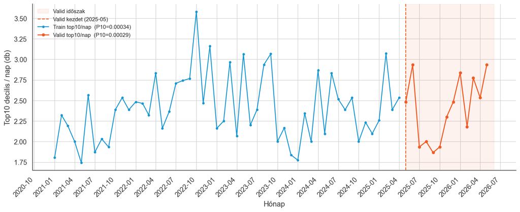

Figure 4: Havi átlagos top10 decilis / nap — Train (kék) és Valid (narancs), szegmensenkénti P10 (short: legnegatívabb 10%)

```python
# Havi plot adatok
plot_rows = []
for seg_label, seg_df, p10 in [("Train", train_df, p10_train), ("Valid", valid_df, p10_valid)]:
    sd = seg_df.copy()
    sd["top10"] = sd[TARGET] <= p10  # short: leg-negatívabb értékek
    sd["ym"]    = sd["open_time"].dt.to_period("M")
    for ym, mdf in sd.groupby("ym"):
        n_t = int(mdf["top10"].sum())
        plot_rows.append({
            "segment":      seg_label,
            "date":         ym.to_timestamp(),
            "top10_per_day": n_t / ym.days_in_month,
        })

plot_df      = pd.DataFrame(plot_rows)
train_plot   = plot_df[plot_df["segment"] == "Train"]
valid_plot   = plot_df[plot_df["segment"] == "Valid"]

valid_start_dt = valid_df["open_time"].min().replace(day=1)
plot_end_dt    = valid_df["open_time"].max().replace(day=1) + pd.DateOffset(months=1)

fig, ax = plt.subplots(figsize=(12, 5))

ax.axvspan(valid_start_dt, plot_end_dt,
           alpha=0.08, color=CQ_COLORS["orange"], label="Valid időszak")
ax.axvline(valid_start_dt, color=CQ_COLORS["orange"], linewidth=1.3, linestyle="--",
           label=f"Valid kezdet ({valid_start_dt.strftime('%Y-%m')})")

ax.plot(train_plot["date"], train_plot["top10_per_day"],
        color=CQ_COLORS["blue"], linewidth=1.4, marker="o", markersize=3,
        label=f"Train top10/nap  (P10={p10_train:.5f})")
ax.plot(valid_plot["date"], valid_plot["top10_per_day"],
        color=CQ_COLORS["orange"], linewidth=1.6, marker="o", markersize=4,
        label=f"Valid top10/nap  (P10={p10_valid:.5f})")

ax.xaxis.set_major_formatter(mdates.DateFormatter("%Y-%m"))
ax.xaxis.set_major_locator(mdates.MonthLocator(bymonth=[1, 4, 7, 10]))
plt.xticks(rotation=45, ha="right")
ax.set_xlabel("Hónap")
ax.set_ylabel("Top10 decilis / nap (db)")
ax.legend(fontsize=9)
plt.tight_layout()
plt.show()
```

## 7 5. Top 10 lift ábrák — Train és Valid

Vizuális áttekintés arról, hogy **mikor és milyen close árfolyam mellett** jelennek meg a top 10% decilisbe eső target (`short_mfe_fw60`) megfigyelések. **Short modellnél: top10 = a legalacsonyabb (leg-negatívabb) értékek (P10 küszöb alattiak).** A piros szaggatott függőleges vonalak mindkét panelen jelzik a top decilis x-pozícióit.

- **Train:** éves alfejezetek, minden évben havi tabset (1 fül = 1 naptári hónap). P10 küszöb: a teljes train halmaz 10. percentilise.
- **Valid:** havi alfejezetek, minden hónapban heti tabset (1 fül = 7 nap). P10 küszöb: a teljes valid halmaz 10. percentilise.

### 7.1 Train — éves bontás, havi tabset

#### 7.1.1 2021

**Jan**

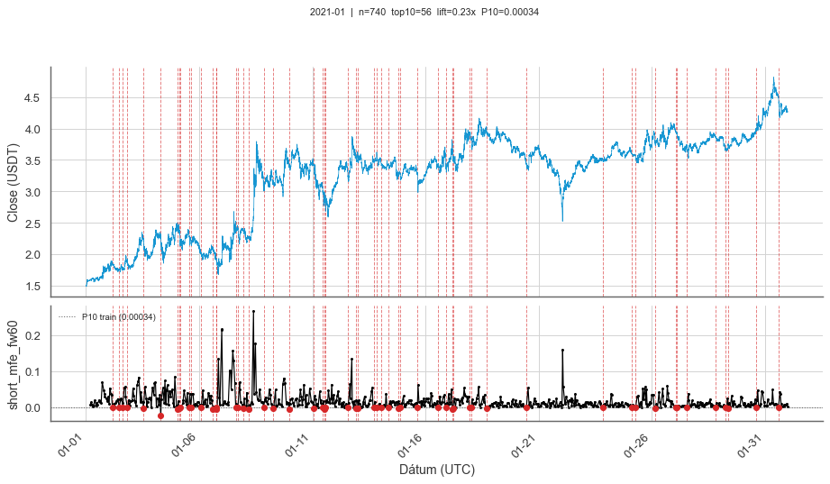

**Feb**

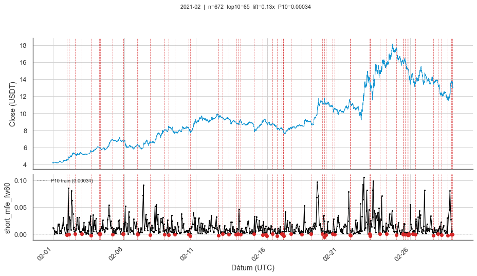

**Mar**

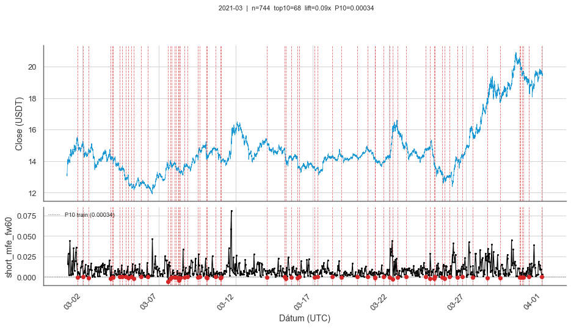

**Apr**

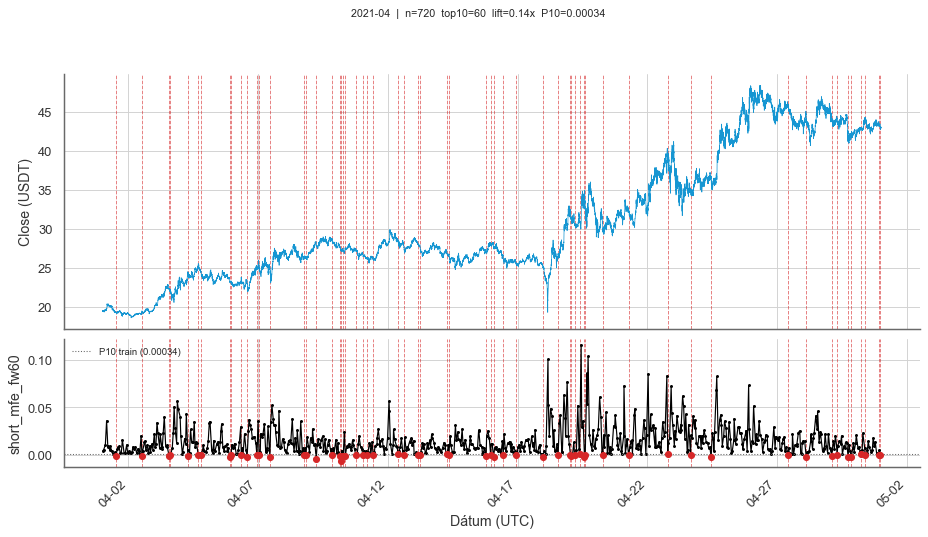

**May**

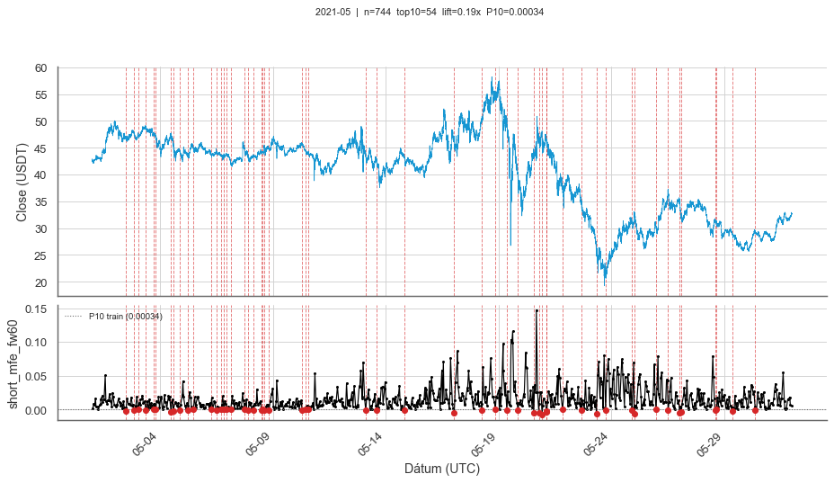

**Jun**

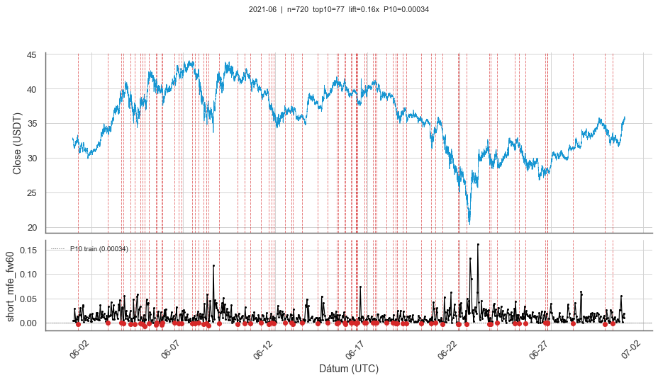

**Jul**

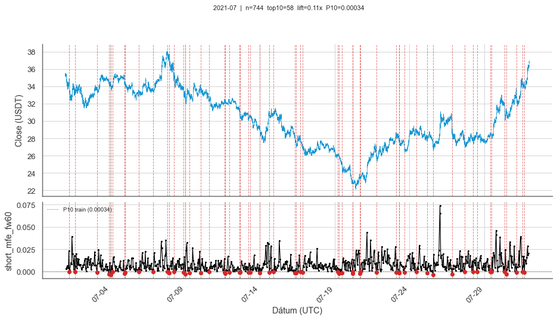

**Aug**

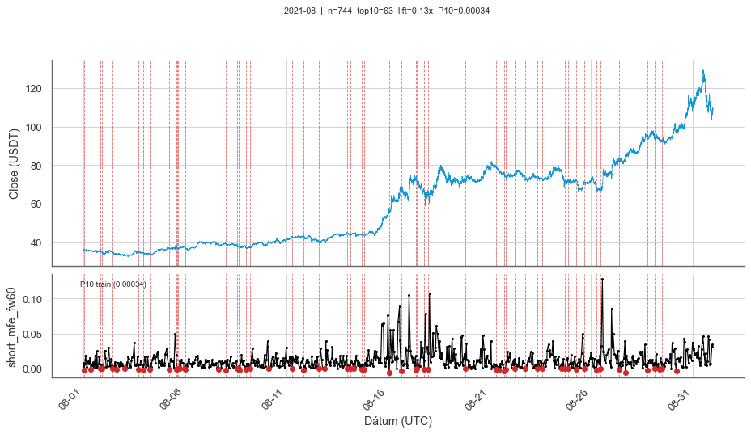

**Sep**

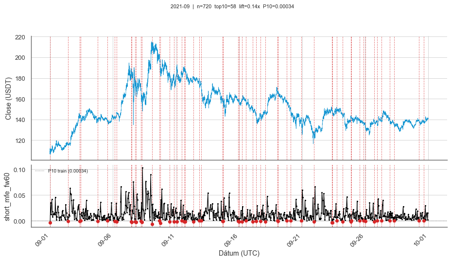

**Oct**

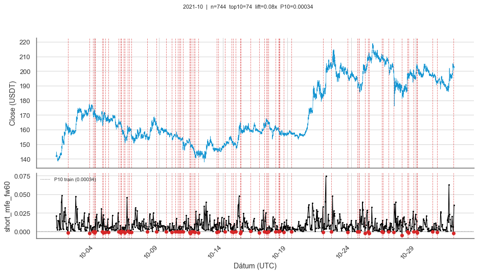

**Nov**

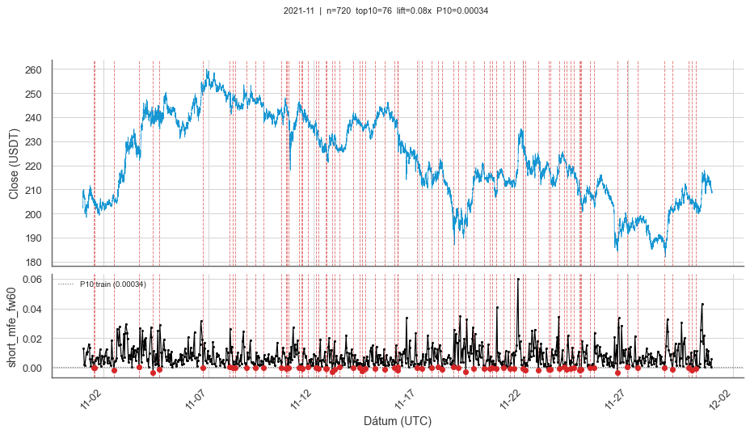

**Dec**

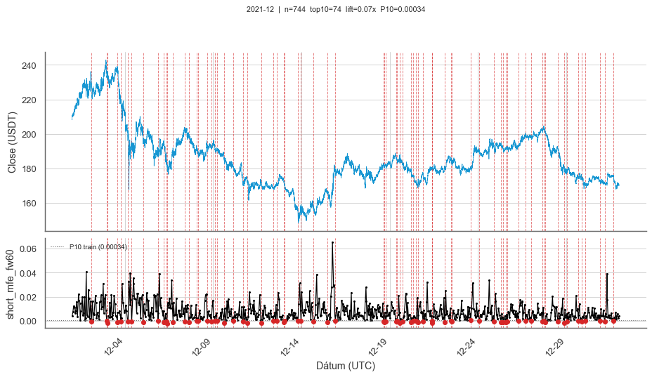

#### 7.1.2 2022

**Jan**

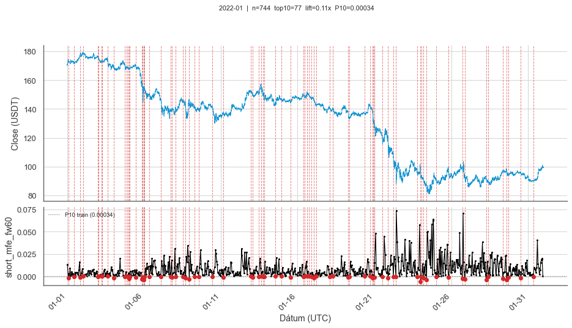

**Feb**

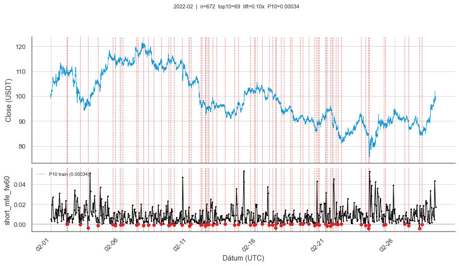

**Mar**

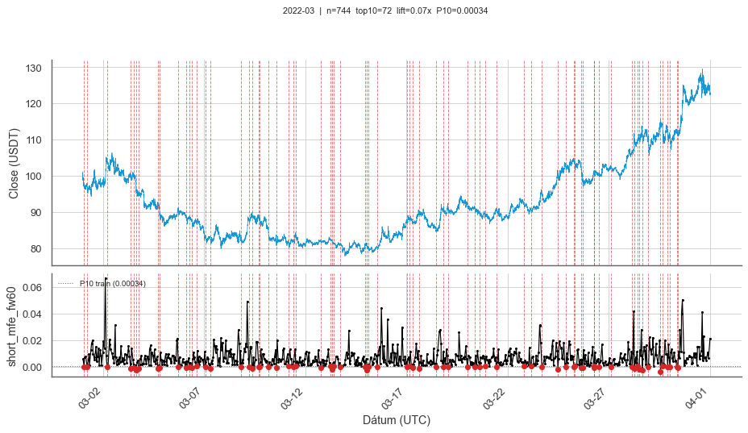

**Apr**

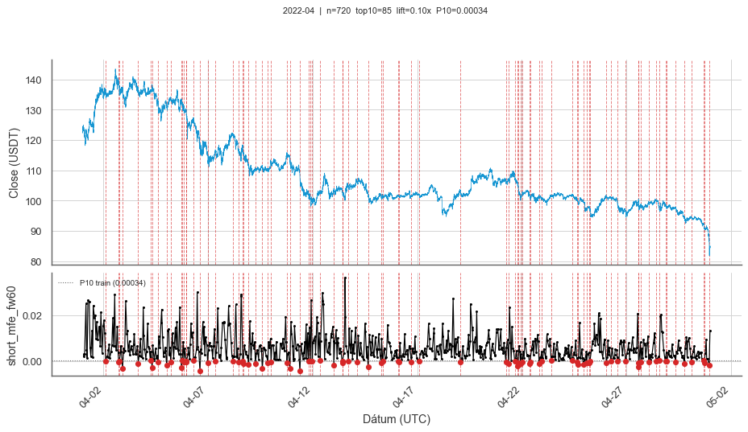

**May**

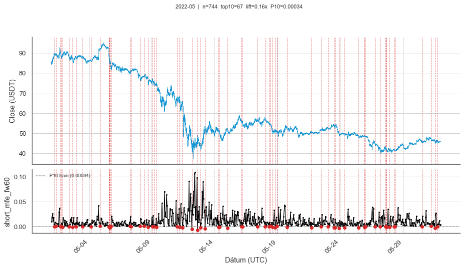

**Jun**

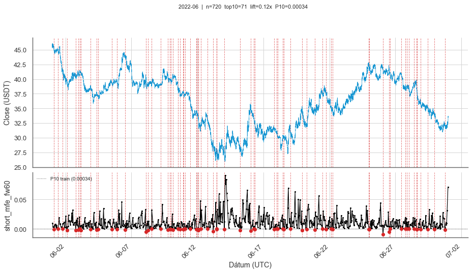

**Jul**

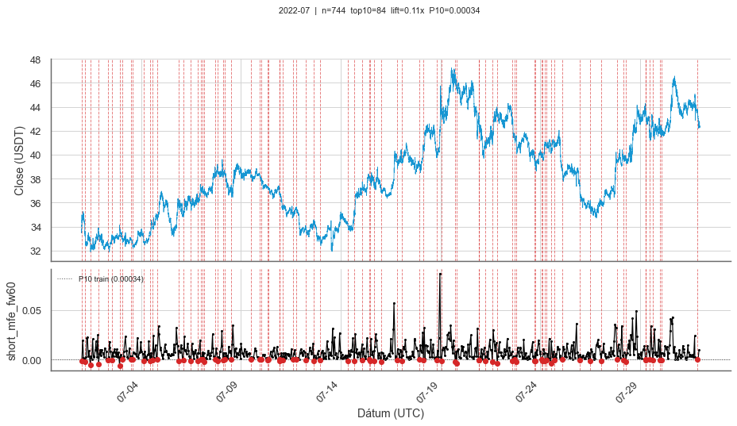

**Aug**

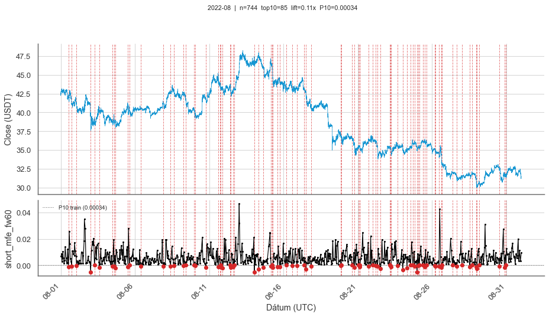

**Sep**

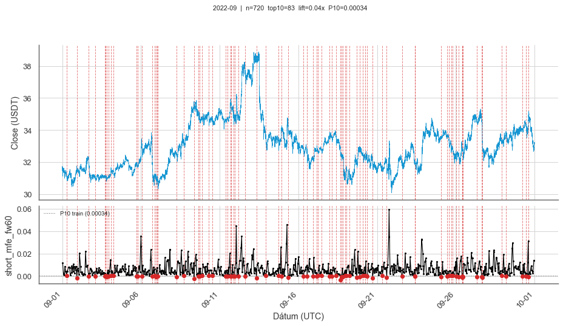

**Oct**

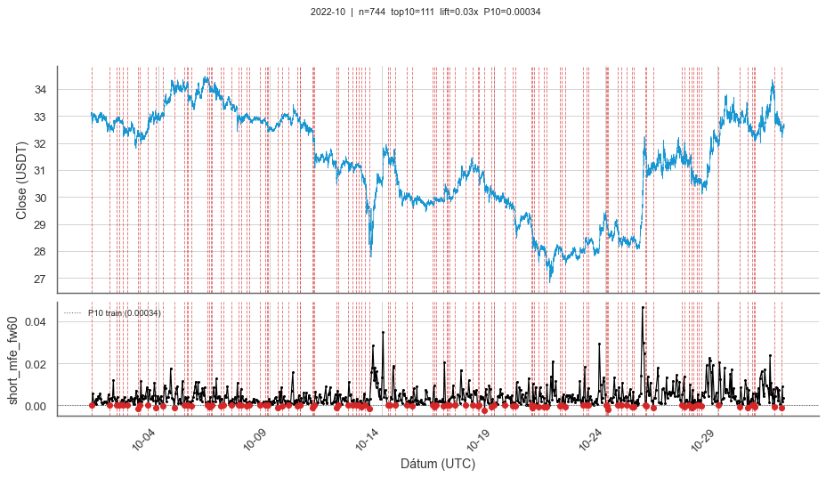

**Nov**

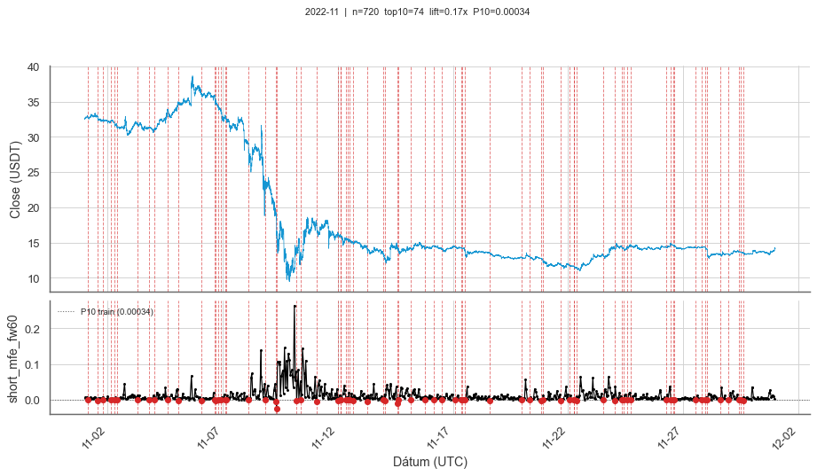

**Dec**

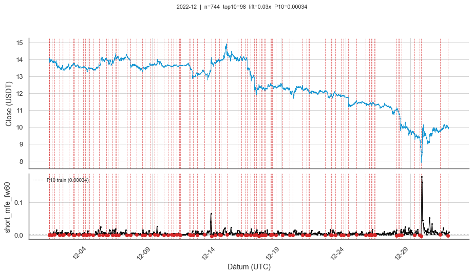